# MAE: Ejercicios Tema 3

# Métodos avanzados en estadística: Entrega Ejercicios 3 - 09/12/2021

## **Adrián Rubio Pintado**

Librerías

```r
library(ggplot2)
library(KernSmooth)
library(dplyr)
```

## **EJERCICIO 1**

**a) El estimador de Nadaraya-Watson puede verse como un caso particular de una clase más amplia de estimadores no paramétricos, los llamados estimadores polinómicos locales. En concreto, Nadaraya-Watson es el que corresponde a realizar un ajuste constante local.**

**b) El grado para el estimador localmente lineal polinomico es 1**

```r
datos1 <- read.table("Datos-geyser.txt",header = TRUE ,sep = "", dec = ".")
df1 <-data.frame(X=datos1$X , Y =datos1$Y )
```

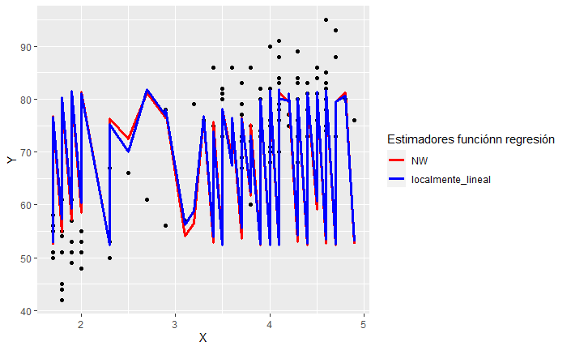

```r
# nota: dpill(X, Y) selecciona un bandwith usando una metodología plug-in
bandwith <- dpill(df1$X, df1$Y)

#Estimador Nadaraya-Watson: estimador localmente constante (p=0 = degree)
ajuste_nw <- with(df1, locpoly(X, Y, degree = 0, bandwidth = bandwith, gridsize = length(df1$X)))
#Estimador localmente lineal (p=1 = degree)
ajuste_ln <- with(df1, locpoly(X, Y, degree = 1, bandwidth = bandwith, gridsize = length(df1$X)))

ggplot(df1) +
  geom_point(mapping = aes(X,Y))+
  #Nadaraya-Watson
  geom_line(aes(X, ajuste_nw$y,  color="NW"), size = 1.1, )+
  #Localmente Lineal
  geom_line(aes(X, ajuste_ln$y, color="localmente_lineal"),  size = 1.1)+
  scale_color_manual(name = "Estimadores funciónn regresión",
                     values = c("NW" = "red", "localmente_lineal" = "blue"))
```

Bandwidth usado para Nadaraya-Watson:

```r
bandwith
```

```
[1] 0.2245031
```

Repetimos el proceso usando ahora loess. Que aunque la estimación difiere de la definición de estimación polinomica local, aunque los principios en los que se basan son los mismos(cogemos una proporcion local de datos del 25%):

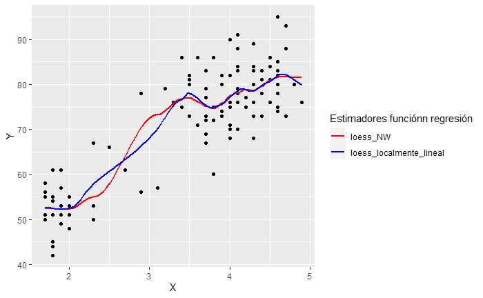

```r
datos1 <- read.table("Datos-geyser.txt",header = TRUE ,sep = "", dec = ".")
df1 <-data.frame(X=datos1$X , Y =datos1$Y )


# Con loess
#proporcion de puntos locales a coger para el entrenamiento local
span <- 0.25
#No utiliza un kernel normal, utiliza un kernel tri-ponderado
# La estimación difiere de la definición de estimación polinomica local, aunque los principios en los que se basan son los mismos

ggplot(df1) +
  geom_point(mapping = aes(X,Y))+

  #loess
  geom_smooth(aes(X, Y, color="loess_NW") ,method = 'loess', se = FALSE,
              span = span, method.args = list(degree=0)) +     #  loess Nadaraya-Watson
  geom_smooth(aes(X, Y,  color="loess_localmente_lineal"), method = 'loess', se = FALSE,
              span = span, method.args = list(degree=1)) + #loess localmente lineal +
  scale_color_manual(name = "Estimadores funciónn regresión",
                     values = c("loess_NW" = "red", "loess_localmente_lineal" = "blue"))
```

```r
NA
```

## **EJERCICIO 4**

**Se considera el siguiente modelo de regresi´on lineal m´ultiple: (…)**

**a) Calcula la tabla de analisis de la varianza para el modelo (1) y contrasta a nivel α = 0,05 la hipotesis nula H0 : β1 = β2 = β3 = 0.**

La tabla anova o de análisis de la varianza nos da(entre otras cosas) la suma de cuadrados explicada SCE para cada submodelo. Disponemos únicamente de la suma de cuadrados residuales SCR.

Para una comparativa de dos submodelos, sabemos que

$$SCR_{0} - SCR = SCE$$
(Perteneciendo $SCR_{0}$ al modelo reducido y SCR al completo ). En un modelo reducido imponemos restricciones, de modo que tiene menos variables que el modelo completo. En nuestro caso, queremos saber el SCE del modelo 1, así que tomamos el $SCR_{0}$ del submodelo que contiene únicamente el término independiente, y como modelo completo el SCR del modelo 1. (NOTA: Siempre se cumple que $SCR_{0}$ > SCR )

$$SCE_{modelo1} = SCR_{0} - SCR_{modelo1} = 42644.00 - 761.41 = 41882.59$$

```r
n <- 20
p <- 3
df = n-p-1

scr0 <-42644.00
scr <- 761.41
sce = scr0-scr


modelo <- c("Modelo 1", "Residuos")
dfs <- c(p, df)
sum_sq <- c(sce,scr)
mean_sq <- sum_sq/dfs
f_statistic <- c((sce/p) /(scr/df), NA)

p_value <- c(pf(f_statistic[1], df1=p, df2=n-p-1, lower.tail=F),   NA)

#anova : Df Sum Sq Mean Sq F value Pr(>F)
tabla_anova <- data.frame(Source=modelo, Df=dfs, Sum_Sq=sum_sq, Mean_Sq=mean_sq, F_statistic=f_statistic, p_value=p_value)
tabla_anova
```

| Source | Df | Sum_Sq | Mean_Sq | F_statistic | p_value |
| --- | --- | --- | --- | --- | --- |
| Modelo 1 | 3 | 41882.59 | 13960.86333 | 293.3686 | 3.421043e-14 |
| Residuos | 16 | 761.41 | 47.58812 | NA | NA |

| Source <chr> | Df <dbl> | Sum_Sq <dbl> | Mean_Sq <dbl> | F_statistic <dbl> | p_value <dbl> |
| --- | --- | --- | --- | --- | --- |
| Modelo 1 | 3 | 41882.59 | 13960.86333 | 293.3686 | 3.421043e-14 |
| Residuos | 16 | 761.41 | 47.58812 | NA | NA |

2 rows

Sabemos que bajo la hipótesis H0 de que todos los beta(excepto el término independiente) son 0, sabemos que el estadístico del modelo es:

$$F = \frac{SCE/p}{SCR/(n-p-1)}$$
y que sigue una distribución
$$F_{p, n-p-1}$$
Obtenemos un p-valor para el estadístico de 3.421043e-14, casi 0, siendo menor que alpha = 0.05, por lo que estamos fuera de la región crítica y podemos rechazar la hipótesis nula.

**b) En el modelo (1), contrasta a nivel α = 0,05 las dos hipotesis nulas siguientes:** Sabemos que bajo estas hipótesis H0 sabemos que el estadístico del modelo es:

$$F = \frac{(SCR_{0} - SCR)/k}{SCR/(n-p-1)}$$
y que sigue una distribución
$$F_{k, n-p-1}$$
Siendo k el número de restricciones que imponemos en la hipótesis nula.(El ejemplo del apartado a era un caso particular de este donde todas las betas son 0 en la hipótesis nula) Dado que tenemos los SCR0 dados en el enunciado, calulamos el estadístico y su p-valor.

```r
k= 1
scr0 = 762.55
f_statistic <-  ((scr0 - scr)/k) / (scr/df)
pvalue <- pf(f_statistic, df1=k, df2=df,lower.tail=F)
pvalue
```

```
[1] 0.8789337
```

Obtenemos un p-valor de 0.8789337 >0.05, por lo que no podemos rechazar la hipótesis nula.

**H0 : β1 = β3 = 0** Para este caso k=2

```r
k= 2
scr0 = 36253.69
f_statistic <-  ((scr0 - scr)/k) / (scr/df)
pvalue <- pf(f_statistic, df1=k, df2=df,lower.tail=F)
pvalue
```

```
[1] 3.785566e-14
```

Obtenemos un p-valor de prácticamente un valor 0, menor que alpha=0.05, teniendo evidencia suficiente para poder rechazar en este caso la hipótesis nula.

Vemos como tiene sentido aceptar y rechazar estos dos casos de hipótesis nulas, ya que en el primer caso no rechazábamos que la variable 2 tuviera poca importancia en el modelo, y en el segundo caso, de que la 1 y la 3 sí la tenían. Podemos ver en la tabla del enuciado, cómo cuando empleamos las variables 1 y 3, el SCR está muy cerca de el del modelo completo, mientras que si usamos solo la variable 2, el SCR se dispara, es decir, la suma de residuos es muy alta, ya que la variable 2 no es significativa para el modelo, y la 1 y la 3 sí lo son.

# *EJERCICIO 6*

**Sean Y1, Y2 e Y3 tres variables aleatorias independientes con distribuci´on normal y varianza σ2.Supongamos que µ es la media de Y1, λ es la media de Y2 y λ + µ es la media de Y3,donde λ, µ ∈ R**

**a) Demuestra que el vector Y = (Y1, Y2, Y3) verifica el modelo de regresi´on m´ultiple Y = Xβ + . Para ello, determina la matriz de dise˜no X, el vector de par´ametros β y la distribuci´on de las variables de error.** Sabemos que

$$Y = X \beta + \epsilon \equiv Y|X \sim N_{n}(X \beta, \sigma^2 I_{n} ) \equiv \epsilon|X \sim N_{n}(0, \sigma^2 I_{n} )$$

Tenemos que

$$Y = \begin{pmatrix} Y_{1}\\ Y_{2}\\ Y_{3} \end{pmatrix} = X \beta + \epsilon$$

Que en forma matricial:

$$Y = \begin{pmatrix} 1 & 0\\ 0 &1 \\ 1&1 \end{pmatrix} \begin{pmatrix} \mu \\ \lambda \end{pmatrix} + \begin{pmatrix} \epsilon_{1}\\ \epsilon_{1} \\ \epsilon_{1} \end{pmatrix}$$

Siendo la primera matriz la de diseño, a continuación el vector de coeficientes y el vector de residuos. De este modo, Y verifica el modelo de regresión multiple.

**b) Calcula los estimadores de m´axima verosimilitud (equivalentemente, de m´ınimos cuadrados) de λ y µ.**

Utilizamos la expresión de estimador de mínimos cuadrados

$$\hat{\beta} = (X'X)^{-1}X'Y$$

El producto $(X'X)$ nos da $\begin{pmatrix} 2 & 1\\ 1 &2 \end{pmatrix}$

Calculamos la inversa, que nos da $(X'X)^{-1} = \begin{pmatrix} 2/3 & -1/3\\ -1/3 &2/3 \end{pmatrix}$

Multiplicando por X dicho resultado y luego por Y obtenemos

$$\hat{\beta} = \frac{1}{3}\begin{pmatrix} 2 & -1 & 1\\ -1 & 2 & 1 \end{pmatrix} \begin{pmatrix} Y_{1}\\ Y_{2}\\ Y_{3} \end{pmatrix}$$
Obteniendo los estimadores de máxima verosimilitud:
$$\hat{\beta} = \begin{pmatrix} \hat{\mu} \\ \hat{\lambda} \end{pmatrix} = \begin{pmatrix} \frac{1}{3}(2Y_{1} - Y_{2} + Y_{3}) \\ \frac{1}{3}(-Y_{1} + 2Y_{2} + Y_{3}) \end{pmatrix}$$
**c) Calcula la distribuci´on del vector (λ, ˆ µˆ), formado por los estimadores calculados en elapartado anterior.** Sabemos que el estimador
$$\hat{\beta} = \begin{pmatrix} \hat{\mu} \\ \hat{\lambda} \end{pmatrix} \sim N_{p+1}(\beta, \sigma^2 (X'X)^{-1})$$
Que aplicado a nuestro caso particular:
$$\hat{\beta} = \begin{pmatrix} \hat{\mu} \\ \hat{\lambda} \end{pmatrix} \sim N_{2}(\begin{pmatrix} \mu \\ \lambda \end{pmatrix}, \sigma^2 \begin{pmatrix} 2/3 & -1/3\\ -1/3 &2/3 \end{pmatrix} )$$

# *EJERCICIO 10*

**Los datos fuel2001 del fichero combustible.RData (v´ease transparencias de clase) corresponden al consumo de combustible (y otras variables relacionadas) enlos estados de EE.UU.Se desea explicar la variable FuelC en funci´on del resto de la informaci´on.**

```r
datos <- 'http://verso.mat.uam.es/~joser.berrendero/datos/combustible.RData'
load(url(datos))
head(fuel2001)
```

|  | Drivers | FuelC | Income | Miles | MPC | Pop | Tax |
| --- | --- | --- | --- | --- | --- | --- | --- |
| AL | 3559897 | 2382507 | 23471 | 94440 | 12737.00 | 3451586 | 18.0 |
| AK | 472211 | 235400 | 30064 | 13628 | 7639.16 | 457728 | 8.0 |
| AZ | 3550367 | 2428430 | 25578 | 55245 | 9411.55 | 3907526 | 18.0 |
| AR | 1961883 | 1358174 | 22257 | 98132 | 11268.40 | 2072622 | 21.7 |
| CA | 21623793 | 14691753 | 32275 | 168771 | 8923.89 | 25599275 | 18.0 |
| CO | 3287922 | 2048664 | 32949 | 85854 | 9722.73 | 3322455 | 22.0 |

|  | Drivers <int> | FuelC <int> | Income <int> | Miles <int> | MPC <dbl> | Pop <int> | Tax <dbl> |
| --- | --- | --- | --- | --- | --- | --- | --- |
| AL | 3559897 | 2382507 | 23471 | 94440 | 12737.00 | 3451586 | 18.0 |
| AK | 472211 | 235400 | 30064 | 13628 | 7639.16 | 457728 | 8.0 |
| AZ | 3550367 | 2428430 | 25578 | 55245 | 9411.55 | 3907526 | 18.0 |
| AR | 1961883 | 1358174 | 22257 | 98132 | 11268.40 | 2072622 | 21.7 |
| CA | 21623793 | 14691753 | 32275 | 168771 | 8923.89 | 25599275 | 18.0 |
| CO | 3287922 | 2048664 | 32949 | 85854 | 9722.73 | 3322455 | 22.0 |

6 rows

```r
fuel_train <- fuel2001[,-c(2)]
#head(fuel_train)
```

**a) Representa en un plano las dos primeras componentes principales de estos datos estandarizados (consulta la ayuda de prcomp). ¿Son suficientes estas dos componentes para explicar un alto porcentaje de la varianza?**

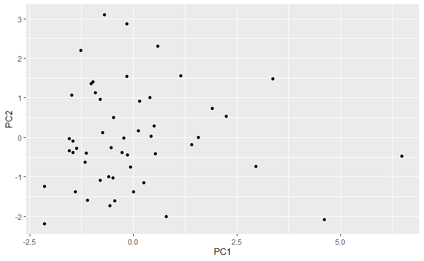

```r
prcomp_fuel <- prcomp(fuel_train, scale =TRUE )
pca_fuel <- data.frame(
  PC1 = prcomp_fuel$x[, 1],
  PC2 = prcomp_fuel$x[, 2]
)
ggplot(pca_fuel, aes(x = PC1, y = PC2)) +
  geom_point()
```

Vamos a ver si son suficientes estas dos componentes para explicar un alto porcentaje de la varianza. Recordamos que para calcular dicho porcentaje usamos:

$$V_{p} = \frac{\lambda_{1} + ... + \lambda_{p}}{\lambda_{1} + ... + \lambda_{d}}$$
Siendo $\lambda$ los autovalores de la matriz de coovarianza muestral, p el número de componentes principales seleccionado y d la dimensionalidad original de los datos.

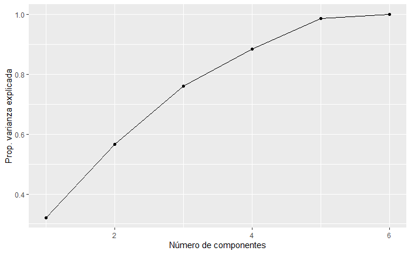

```r
var_acumulada <- cumsum(prcomp_fuel$sdev) / sum(prcomp_fuel$sdev)
sdev <- data.frame(indice = 1:6, var_acumulada)
ggplot(sdev, aes(x = indice, y = var_acumulada)) +
  geom_line() +
  geom_point() +
  labs(x = "Número de componentes", y = "Prop. varianza explicada")
```

**(b) Ajusta el modelo completo con todas las variables. En este modelo completo, contrasta la hip´otesis nula de que los coeficientes de las variables Income, MPC y Tax son simult´aneamente iguales a cero.**

```r
# Modelo completo
modelo_completo <- lm(FuelC ~ Drivers + Income + Miles + MPC + Pop + Tax,
                      data=fuel2001)
summary(modelo_completo)
```

```
Call:
lm(formula = FuelC ~ Drivers + Income + Miles + MPC + Pop + Tax,
    data = fuel2001)

Residuals:
     Min       1Q   Median       3Q      Max
-1480910  -158802    19267   174208  1090089

Coefficients:
              Estimate Std. Error t value Pr(>|t|)
(Intercept) -4.902e+05  8.199e+05  -0.598 0.552983
Drivers      6.368e-01  1.452e-01   4.386 7.09e-05 ***
Income       7.690e+00  1.632e+01   0.471 0.639793
Miles        5.850e+00  1.621e+00   3.608 0.000784 ***
MPC          4.562e+01  3.565e+01   1.280 0.207337
Pop         -1.945e-02  1.245e-01  -0.156 0.876586
Tax         -2.087e+04  1.324e+04  -1.576 0.122235
---
Signif. codes:  0 ‘***’ 0.001 ‘**’ 0.01 ‘*’ 0.05 ‘.’ 0.1 ‘ ’ 1

Residual standard error: 398400 on 44 degrees of freedom
Multiple R-squared:  0.9808,    Adjusted R-squared:  0.9782
F-statistic: 374.6 on 6 and 44 DF,  p-value: < 2.2e-16
```

```r
# Modelo reducido
modelo_reducido <- lm(FuelC ~ Drivers   + Miles  + Pop  ,
                      data=fuel2001)
anova(modelo_reducido, modelo_completo)
```

```
Analysis of Variance Table

Model 1: FuelC ~ Drivers + Miles + Pop
Model 2: FuelC ~ Drivers + Income + Miles + MPC + Pop + Tax
  Res.Df        RSS Df  Sum of Sq      F Pr(>F)
1     47 7.8556e+12
2     44 6.9843e+12  3 8.7128e+11 1.8296 0.1557
```

Obtenemos un estadístico F con un p-valor de 0.1557, el cual es mayor que alpha=0.05, por lo cual no tenemos evidencia suficiente como para poder rechazar la hipótesis nula. Es decir, no podemos afirmar que las condiciones impuestas en la hipótesis nula de que las variables Income, MPC y Tax, son simultáneamente iguales a cero.

**(c) De acuerdo con el metodo iterativo hacia adelante y el criterio BIC, ¿cual es el modelo optimo?**

```r
modelo_forward <- leaps::regsubsets(FuelC ~ . , data=fuel2001 , method='forward')
resumen_forward <- summary(modelo_forward)
resumen_forward
```

```
Subset selection object
Call: regsubsets.formula(FuelC ~ ., data = fuel2001, method = "forward")
6 Variables  (and intercept)
        Forced in Forced out
Drivers     FALSE      FALSE
Income      FALSE      FALSE
Miles       FALSE      FALSE
MPC         FALSE      FALSE
Pop         FALSE      FALSE
Tax         FALSE      FALSE
1 subsets of each size up to 6
Selection Algorithm: forward
         Drivers Income Miles MPC Pop Tax
1  ( 1 ) "*"     " "    " "   " " " " " "
2  ( 1 ) "*"     " "    "*"   " " " " " "
3  ( 1 ) "*"     " "    "*"   " " " " "*"
4  ( 1 ) "*"     " "    "*"   "*" " " "*"
5  ( 1 ) "*"     "*"    "*"   "*" " " "*"
6  ( 1 ) "*"     "*"    "*"   "*" "*" "*"
```

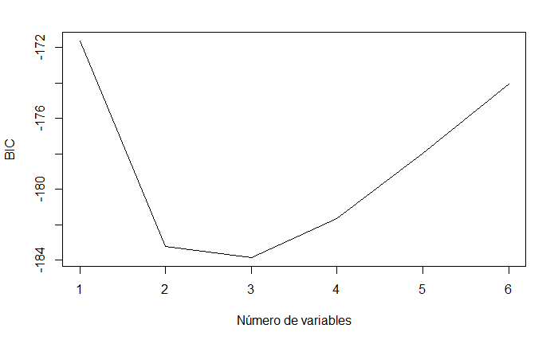

```r
plot(resumen_forward$bic ,xlab =" Número de variables ",
     ylab="BIC",type="l")
```

El mejor modelo con el criterio bic es el modelo de 3 variables(Drivers, Miles y Tax). Ya que el criterio bic penaliza más los modelos con muchas variables, por lo que suele seleccionar modelos más sencillos. Cabe destacar que este método(hacia delante) no garantiza la selección del mejor modelo óptimo global.

**(d) Ajusta el modelo usando lasso, con el parametro de regularizacion seleccionado mediantevalidaci´on cruzada.**

```r
library(glmnet)
x <- as.matrix(fuel2001[,-2])
y <- fuel2001[,2]
```

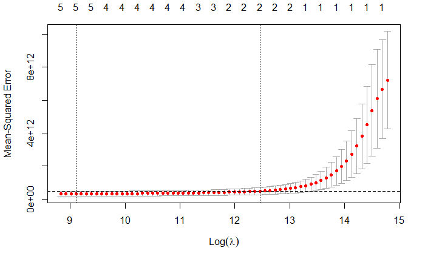

```r
lasso_cv <- cv.glmnet (x , y, alpha = 1)
plot(lasso_cv)
indice <- which(min(lasso_cv$cvm) == lasso_cv$cvm)
abline(h = lasso_cv$cvm[indice] + lasso_cv$cvsd[indice], lty = 2) # para interpretar el criterio de selección
```

Los puntos rojos corresponden al error cuadrático medio (ECM) de predicción estimado mediante validación cruzada. La línea vertical discontinua de la izquierda corresponde al valor de λ que da lugar al mínimo ECM estimado. La línea vertical discontinua de la derecha es el máximo λ tal que su ECM estimado es inferior a su error típico.Este último valor está incluido en lasso_cv$lambda.1se.

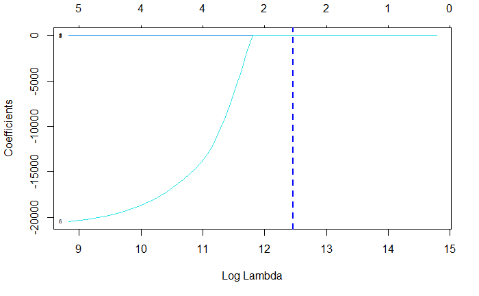

```r
modelo_lasso <- glmnet(x, y, alpha = 1)   # alpha = 1 (lasso)
lambda.lasso = lasso_cv$lambda.1se
plot(modelo_lasso, xvar='lambda', label=TRUE)
abline(v = log(lambda.lasso), lty=2, col='blue', lwd=2)
```

```r
lambda.lasso = lasso_cv$lambda.1se
modelo_final_lasso <- glmnet(x, y, alpha = 1, lambda = lambda.lasso)
coef(modelo_final_lasso)
```

```
7 x 1 sparse Matrix of class "dgCMatrix"
                      s0
(Intercept) 1.528385e+05
Drivers     5.731942e-01
Income      .
Miles       3.102360e+00
MPC         .
Pop         .
Tax         .
```

**(e) Ajusta el modelo usando ridge, con el parametro de regularizacion seleccionado mediante validación cruzada.**

Para ajustar por ridge, tenemos que cambiar el alpha anterior d la libería glmnet por un valor de 0.

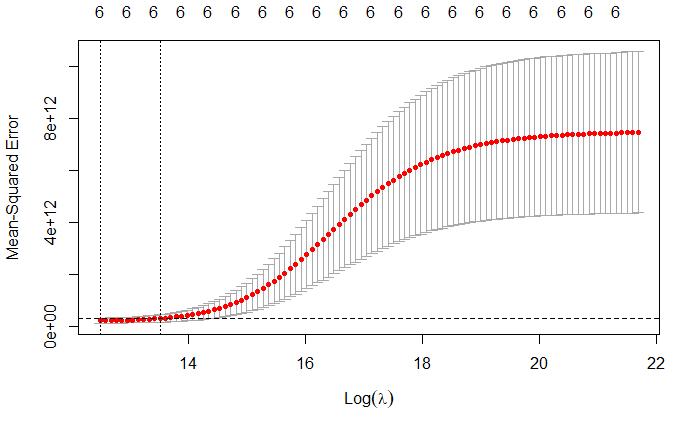

```r
ridge_cv <- cv.glmnet (x , y, alpha = 0)
plot(ridge_cv)
indice <- which(min(ridge_cv$cvm) == ridge_cv$cvm)
abline(h = ridge_cv$cvm[indice] + ridge_cv$cvsd[indice], lty = 2) # para interpretar el criterio de selección
```

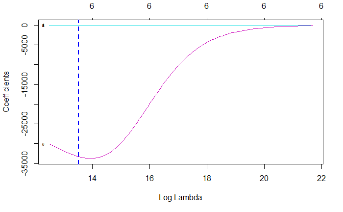

```r
modelo_ridge <- glmnet(x, y, alpha = 0)   # alpha = 0 (ridge)
lambda.ridge = ridge_cv$lambda.1se
plot(modelo_ridge, xvar='lambda', label=TRUE)
abline(v = log(lambda.ridge), lty=2, col='blue', lwd=2)
```

```r
lambda.ridge = ridge_cv$lambda.1se
modelo_final_ridge<- glmnet(x, y, alpha = 0, lambda = lambda.ridge)
coef(modelo_final_ridge)
```

```
7 x 1 sparse Matrix of class "dgCMatrix"
                       s0
(Intercept)  9.667589e+04
Drivers      2.590867e-01
Income       1.910420e+01
Miles        8.968968e+00
MPC          2.031487e+00
Pop          2.083279e-01
Tax         -3.327635e+04
```

En este caso vemos como Ridge utiliza todas las variables. Como observamos en la gráfica, la que mayor influencia que tiene sobre el modelo es la variable 6, es decir Tax, los impuestos, ya que es la que más alejada está de 0.